# Exam 1

## Exam 1

#### Metainformation

1. | Tag | Value |
   | --- | --- |
   | `file` | Inferential_Statistics_vufsw-pvalue-0102-nl_vufsw-pvalue-0102-nl |
   | `name` | vufsw-pvalue-0102-nl |
   | `section` | inferential statistics/nhst/p-value |
   | `type` | schoice |
   | `solution` | TRUE, FALSE, FALSE, FALSE, FALSE, FALSE |
   | `ID` | bd828 |
   | `Type` | interpretating output |
   | `Program` | NA |
   | `Language` | Dutch |
   | `Level` | statistical literacy |

#### Question

   Hieronder staan de resultaten van een meervoudige regressie-analyse met de mate van vertrouwen in de politie (variabele: **Rapportcijfer_politie**) als afhankelijke variabele, gemeten op een schaal die loopt van 1 (heel weinig vertrouwen) t/m 10 (heel veel vertrouwen). De drie onafhankelijke variabelen in het model zijn:
   - **Migratieachtergrond**: 0 = nee; 1 = ja.
   - **Leeftijdscategorie**: gemeten met een schaal met vijf categorieën die oplopen van score 0 (16 t/m 19 jaar) tot en met 4 (65 jaar of ouder).
   - **Opleidingsniveau**: de hoogste opleiding die een respondent momenteel volgt of al afgerond heeft, gemeten met een schaal met zes categorieën die oplopen van score 0 (geen enkele opleiding) t/m score 5 (Wetenschappelijk Onderwijs).

   Leeftijdscategorie en opleidingsniveau hebben een ordinaal meetniveau, maar zullen we voor het gemak als kwantitatief beschouwen.

   Heeft leeftijdscategorie een significante invloed op het vertrouwen in de politie? En waaruit kun je dat opmaken? De onderzoeker toetst tweezijdig met α = 0,05 (alpha =5%).

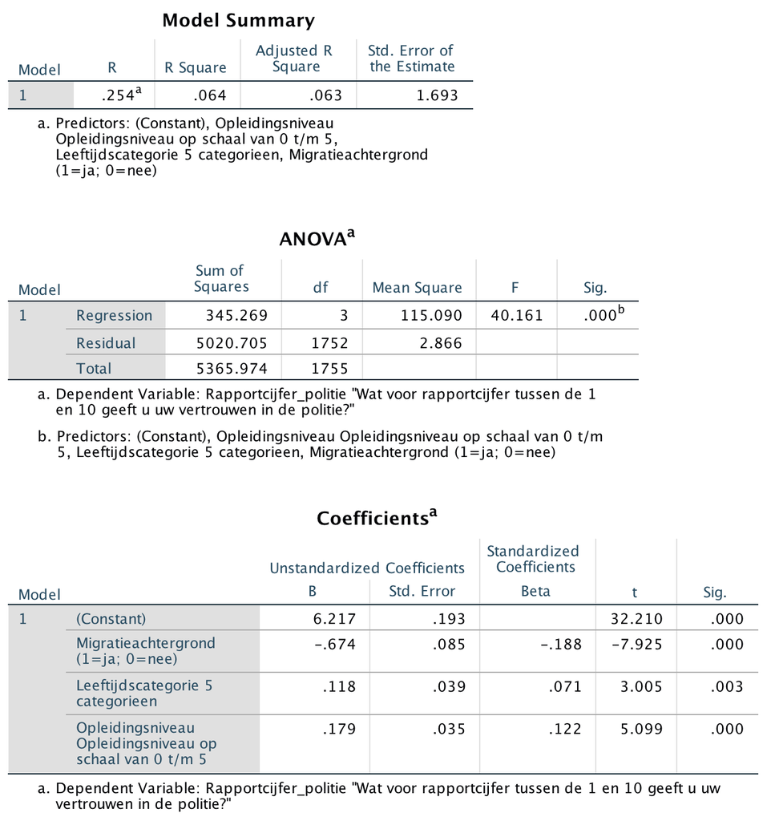

   1. **TRUE:** **Ja**, leeftijdscategorie heeft een significante invloed, omdat de **P-waarde** kleiner is dan 0,05.
   2. **FALSE:** **Ja**, leeftijdscategorie heeft een significante invloed, omdat de **t-waarde** groter is dan 0,05.
   3. **FALSE:** **Ja**, leeftijdscategorie heeft een significante invloed, omdat de **Beta** (gestandaardiseerde b-coëfficient) groter is dan 0,05.
   4. **FALSE:** **Nee**, leeftijdscategorie heeft *geen* significante invloed, omdat de **Beta** (gestandaardiseerde b-coëfficient) groter is dan 0,05.
   5. **FALSE:** **Nee**, leeftijdscategorie heeft *geen* significante invloed, omdat de **t-waarde** groter is dan 0,05.
   6. **FALSE:** **Nee**, leeftijdscategorie heeft *geen* significante invloed, omdat de **P-waarde** kleiner is dan 0,05.

#### Solution

   Language  
   Nederlands

   Levels of Difficulty  
   Easy

   M&T Basics of quantitative research  
   Basics of quantitative research

   M&T BIS  
   Default value
   1. True
   2. False
   3. False
   4. False
   5. False
   6. False